# L05 Maps

Data Visualization (STAT 302)

Noah Holubow

## Overview

The goal of this lab is to explore various was of building maps with `ggplot2`.

Challenges are not mandatory for students to complete. We highly recommend students attempt them though. *We would expect graduate students to attempt the challenges.*

## Datasets

We’ll be using the `US_income.rda` dataset which is already in the `/data` subdirectory in our **data_vis_labs** project. You’ll also be downloading your own data to build maps.

```r
# Load package(s)
library(tidyverse)
library(dplyr)

# Load dataset(s)
load("data/US_income.rda")
```

## Exercises

### Exercise 1

#### Plot 1

Make a county map of a US state using `geom_polygon()`. Maybe use your home state (mine is below) or a favorite state. Please do not use the the state in example provided in the book.

Optional: Consider adding major cities (or your home town).

*Hints:*

- See section [6.1](https://ggplot2-book.org/maps.html#polygonmaps) in our book.
- Void theme

**Answer:**

```r
# creating counties
ca_counties <- map_data("county", "california") %>%
  select(lon = long, lat = lat, group, id = subregion)
head(ca_counties)
```

```
##         lon      lat group      id
## 1 -121.4785 37.48290     1 alameda
## 2 -121.5129 37.48290     1 alameda
## 3 -121.8853 37.48290     1 alameda
## 4 -121.8968 37.46571     1 alameda
## 5 -121.9254 37.45998     1 alameda
## 6 -121.9483 37.47717     1 alameda
```

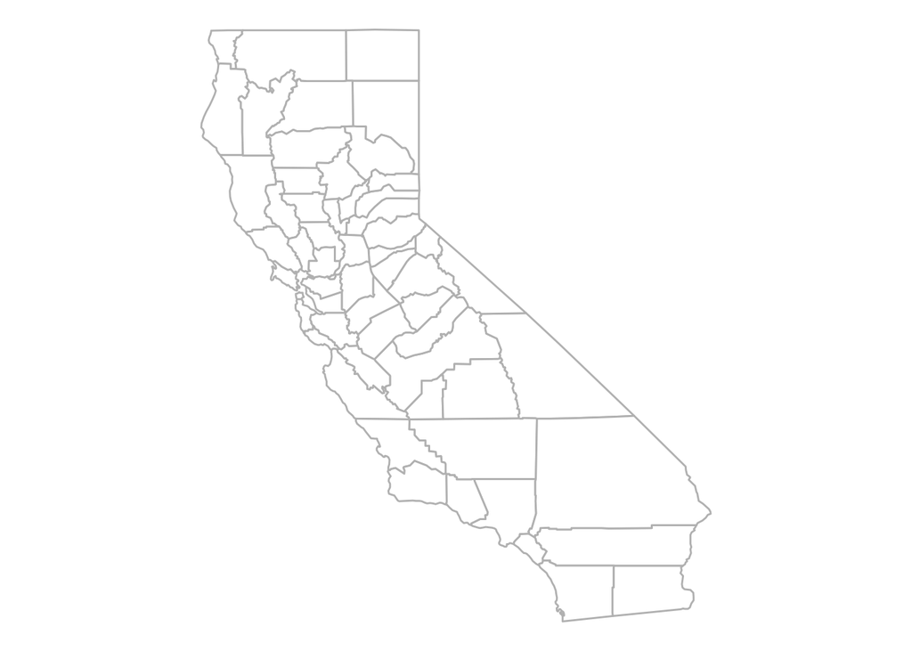

```r
# plotting counties
ggplot(ca_counties, aes(lon, lat, group = group)) +
  geom_polygon(fill = "white", colour = "gray") +
  coord_quickmap() +
  theme_void()
```

#### Plot 2

Now use `geom_sf()` instead. You’ll need to download data for this. You can use either the `tigris` ([github page](https://github.com/walkerke/tigris)) or `raster` packages. Either `tigris`’ `counties()` with `cb = TRUE` or `raster`’s `getData()` could be useful.

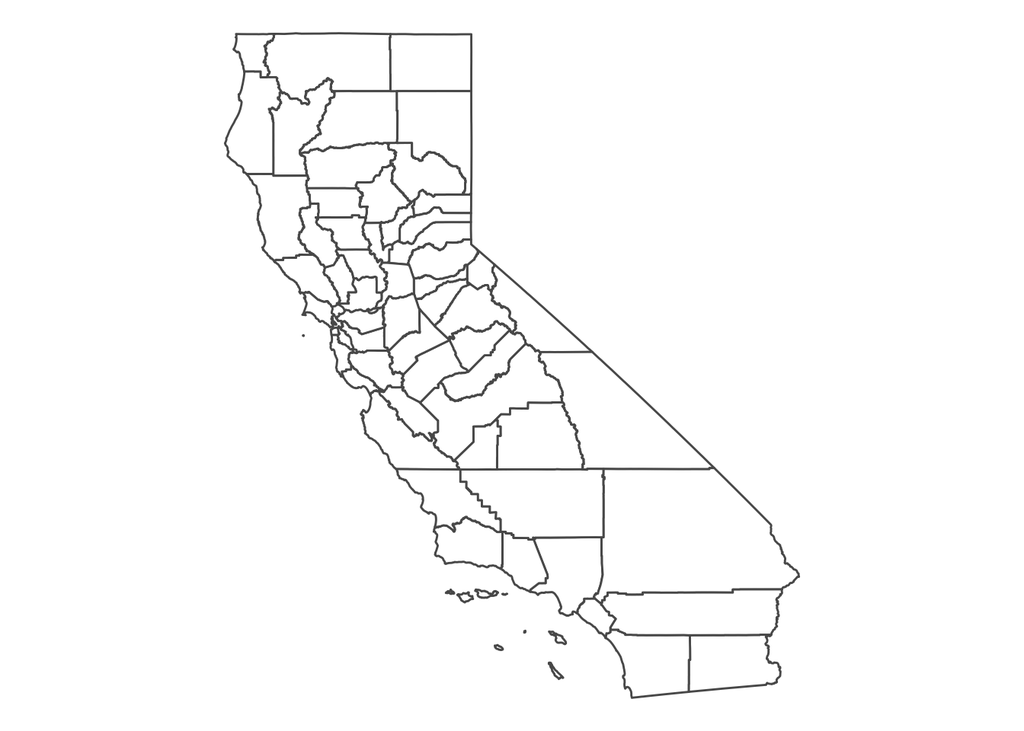

```r
# plot
ggplot(california) +
  geom_sf(fill = "white") +
  coord_sf() +
  theme_void()
```

### Exercise 2

Using `US_income` dataset, recreate the following graphics as precisely as possible.

```r
# Setting income levels
US_income <- mutate(
  US_income,
  income_bins = cut(
    ifelse(is.na(median_income), 25000, median_income),
    breaks = c(0, 40000, 50000, 60000, 70000, 80000),
    labels = c("< $40k", "$40k to $50k",
               "$50k to $60k", "$60k to $70k", "> $70k"),
    right = FALSE
  )
)
```

##### Plot 1

*Hints:*

- `geom_sf()` — boundary color is `"grey80"` and size is 0.2
- `viridis` package (`discrete = TRUE` in `scale_*` function)
- Void theme

**Answer:**

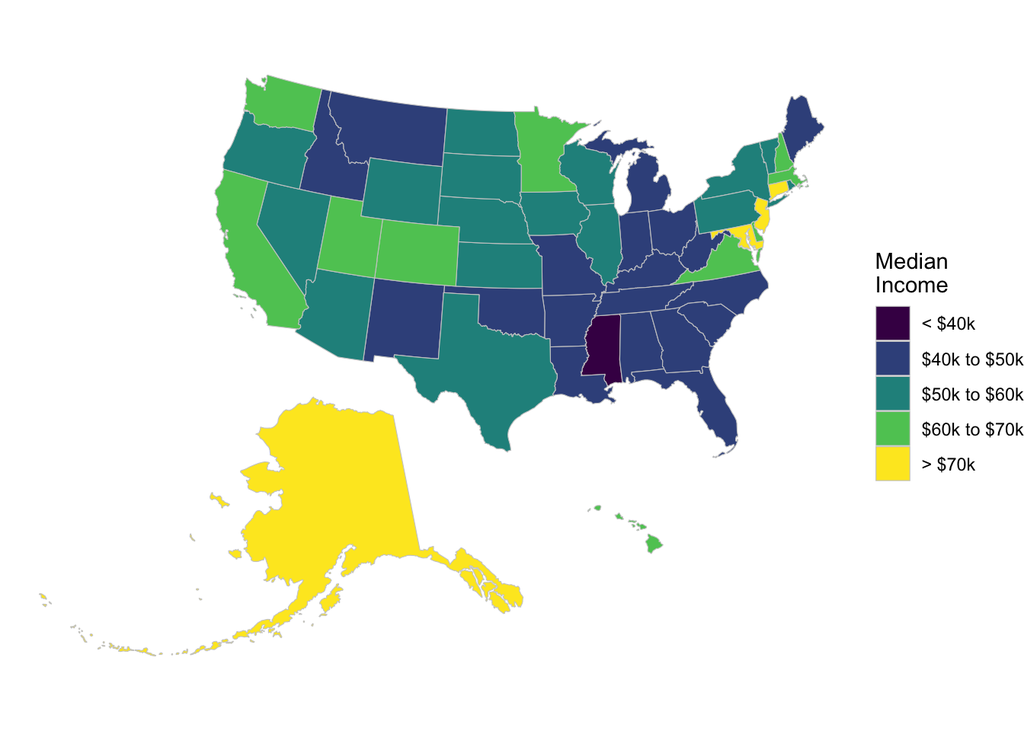

```r
# plot
US_income %>%
  ggplot() +
  geom_sf(aes(fill = income_bins), color = "grey80", size = 0.2) +
  viridis::scale_fill_viridis(discrete = TRUE) +
  coord_sf() +
  labs(
    fill = "Median \nIncome"
  ) +
  theme_void()
```

##### Plot 2

*Hints:*

- [Download developmental version](https://github.com/hrbrmstr/statebins) of `statebins` package
- `geom_statebins()`
- `viridis` package (`discrete = TRUE` in `scale_*` function)
- Statebins theme

**Answer:**

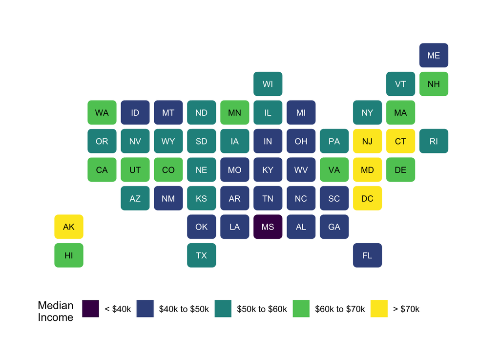

```r
# plot
US_income %>%
  ggplot() +
  statebins::geom_statebins(aes(state = name, fill = income_bins)) +
  viridis::scale_fill_viridis(discrete = TRUE) +
  statebins::theme_statebins(legend_position = "bottom") +
  labs(
    fill = "Median \nIncome"
  )
```

### Exercise 3

Pick any city or foreign country to build a map for. You can dress it up or make it as basic as you want. Also welcome to try building a graphic like that depicted at the end of section [6.5](https://ggplot2-book.org/maps.html#rastermaps) — use a different region though.

**Answer:**

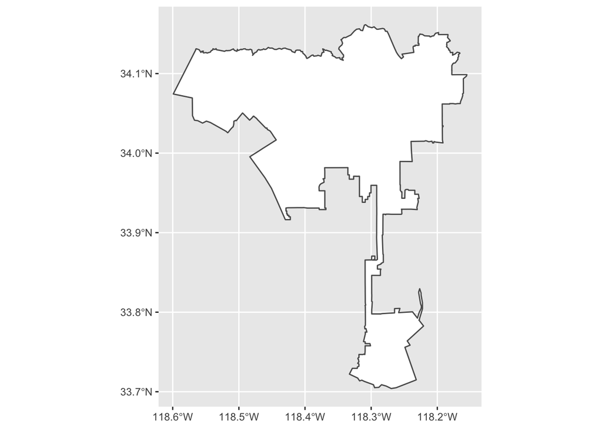

```r
# plot
ggplot(los_angeles) +
  geom_sf(fill = "white") +
  coord_sf()
```

## Challenge(s)

Hint: You’ll need a developmental version of `mapview` package. To get this you need to run the following code in your console

```r
remotes::install_github("r-spatial/mapview")
```